# Transforming data, with solutions (ds4psy)

## Exercise 3

#### Outliers

This exercise examines different possibilities for defining *outliers* and uses a generated dataset (entitled `out.csv` and available at http://rpository.com/ds4psy/data/out.csv) to illustate and compare them. It also helps to further disentangle the difference between `mutate` and *grouped* `mutate` commands.

#### Data on `outliers`

Use the following `read_csv()` command to obtain and load the data into an R object entitled `outliers`:

```r
## Load data (as comma-separated file):
outliers <- read_csv("http://rpository.com/ds4psy/data/out.csv")  # from online source

## Alternatively (from local source):
# outliers <- read_csv("out.csv")  # from current directory
```

#### Not all outliers are alike

An *outlier* can be defined as an individual whose value in some variable deviates by more than a given criterion (e.g., 2 standard deviations) from the mean of the variable. However, this definition is incomplete unless it also specifies the *reference group* over which the means and deviations are computed. In the following, we explore the implications of different reference groups.

#### Basic tasks

- Save the data into a tibble `outliers` and report its number of observations and variables, and their types.
- How many missing data values are there in `outliers`?
- What is the gender (or `sex`) distribution in this sample?
- Create a plot that shows the distribution of `height` values for each gender.

```r
# Load and inspect data:
# outliers <- read_csv("out.csv") # read in csv-file
# outliers <- as_tibble(data)   # if data is not already a tibble
dim(outliers)  # => 1000 observations (rows) x 3 variables (columns)
```

```
#> [1] 1000    3
```

```r
# Missing data points:
sum(is.na(outliers))  # => 18 missing values
```

```
#> [1] 18
```

```r
# Gender distribution:
outliers %>%
  group_by(sex) %>%
  count()
```

```
#> # A tibble: 2 x 2
#> # Groups:   sex [2]
#>   sex        n
#>   <chr>  <int>
#> 1 female   507
#> 2 male     493
```

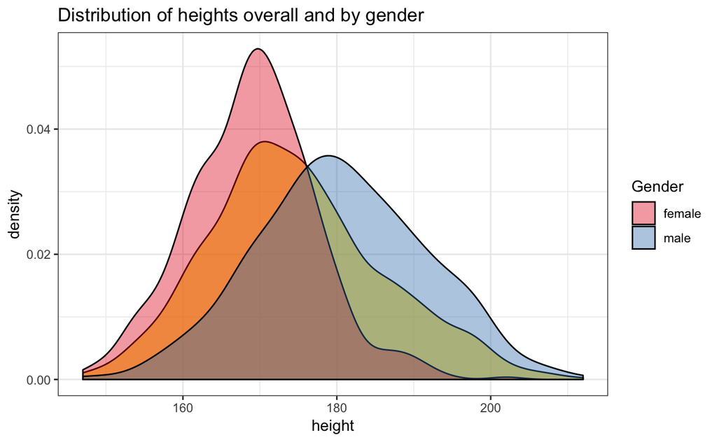

```r
# => 50.7% females, 49.3% males.

# Distributions of `height` as density plot:
ggplot(outliers, aes(x = height)) +
  geom_density(fill = "gold", alpha = 2/3) +
  geom_density(aes(fill = sex), alpha = 2/5) +
  labs(title = "Distribution of heights overall and by gender",
       fill = "Gender") +
  # scale_fill_manual(values = c("firebrick", "steelblue3")) +
  scale_fill_brewer(palette = "Set1") +  # using Brewer palette
  theme_bw()
```

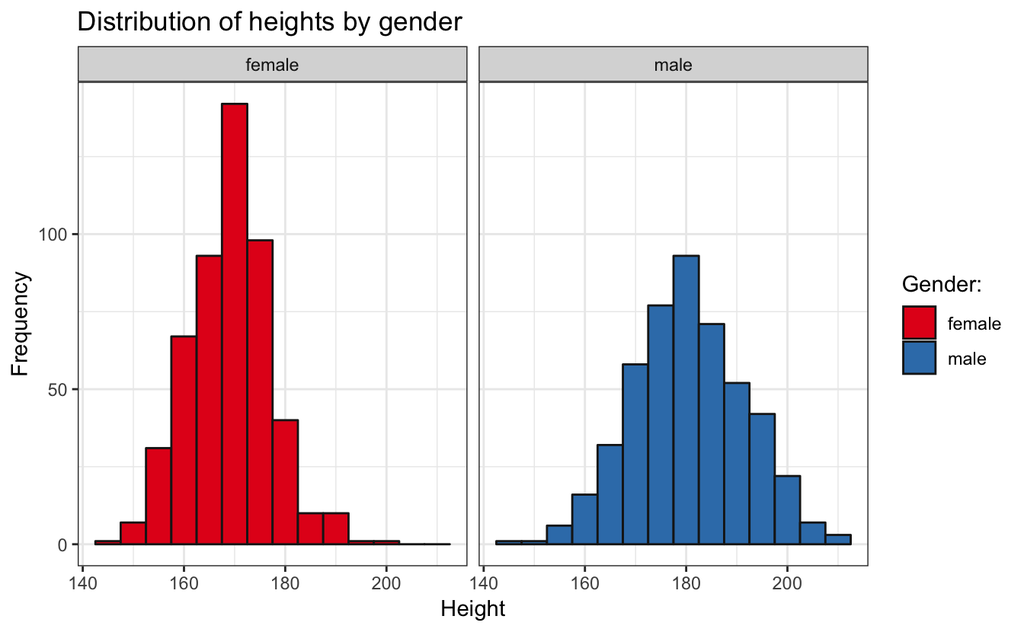

```r
# Note: To avoid the warning about removing 18 cases with NA-values,
#       we could first filter out those cases:
# non_NA_data <- filter(outliers, !is.na(height))

# Alternative solution as 2 histograms:
ggplot(outliers) +
  facet_wrap(~sex) +
  geom_histogram(aes(x = height, fill = sex), binwidth = 5, color = "grey10") +
  labs(title = "Distribution of heights by gender",
       x = "Height", y = "Frequency") +
  scale_fill_brewer(name = "Gender:", palette = "Set1") +  # using Brewer palette
  # scale_fill_manual(name = "Gender:", values = c("firebrick", "steelblue3")) +
  theme_bw()
```

#### Defining different outliers

Compute 2 new variables that signal and distinguish between 2 types of outliers in terms of `height`:

1. outliers relative to the `height` of the *overall sample* (i.e., individuals with `height` values deviating more than 2 SD from the overall mean of `height`);
2. outliers relative to the `height` of *some subgroup*’s mean and SD. Here, a suitable subgroup to consider is every person’s gender (i.e., individuals with `height` values deviating more than 2 SD from the mean `height` of their own gender).

**Hints:** As both variable signal whether or not someone is an outlier they should be defined as logicals (being either `TRUE` or `FALSE`) and added as new columns to `data` (via appropriate `mutate` commands). While the 1st variable can be computed based on the mean and SD of the overall sample, the 2nd variable can be computed after grouping `outliers` by gender and then computing and using the corresponding mean and SD values. The absolute difference between 2 numeric values `x` and `y` is provided by `abs(x - y)`.

#### Relative outliers

Now use the 2 new outlier variables to define (or `filter`) 2 subsets of the data that contain 2 subgroups of people:

1. `out_1`: Individuals (females and males) with `height` values that are outliers relative to *both* the entire sample *and* the sample of their own gender. How many such individuals are in `outliers`?
2. `out_2`: Individuals (females and males) with `height` values that are *not* outliers relative to the entire population, but *are* outliers relative to their own gender. How many such individuals are in `outliers`?

```r
## Defining different outliers: -----

# Included in data_out (below), but also possible to do separately:
# Compute the number, means and SD of height values in 2 ways:

# 1. overall:
outliers %>%
  summarise(n = n(),
            n_not_NA = sum(!is.na(height)),
            mn_height = mean(height, na.rm = TRUE),
            sd_height = sd(height, na.rm = TRUE))
```

```
#> # A tibble: 1 x 4
#>       n n_not_NA mn_height sd_height
#>   <int>    <int>     <dbl>     <dbl>
#> 1  1000      982      175.      11.3
```

```r
# 2. by gender:
outliers %>%
  group_by(sex) %>%
  summarise(n = n(),
            n_not_NA = sum(!is.na(height)),
            mn_height = mean(height, na.rm = TRUE),
            sd_height = sd(height, na.rm = TRUE))
```

```
#> # A tibble: 2 x 5
#>   sex        n n_not_NA mn_height sd_height
#>   <chr>  <int>    <int>     <dbl>     <dbl>
#> 1 female   507      501      169.      8.19
#> 2 male     493      481      181.     11.0
```

```r
# Detecting and marking outliers (by logical variables):
# Compute the means, SDs, and corresponding outliers in 2 ways:
crit <- 2  # criterion value for detecting outliers (in SD units)

data_out <- outliers %>%
  # 1. Compute means, SD, and outliers for overall sample:
  mutate(mn_height  = mean(height, na.rm = TRUE),
         sd_height  = sd(height, na.rm = TRUE),
         out_height = abs(height - mn_height) > (crit * sd_height)) %>%
  group_by(sex) %>%
  # 2. Compute same metrics for subgroups (by sex):
  mutate(mn_sex_height  = mean(height, na.rm = TRUE),
         sd_sex_height  = sd(height, na.rm = TRUE),
         out_sex_height = abs(height - mn_sex_height) > (crit * sd_sex_height))

knitr::kable(head(data_out))
```

| id | sex | height | mn_height | sd_height | out_height | mn_sex_height | sd_sex_height | out_sex_height |
| --- | --- | --- | --- | --- | --- | --- | --- | --- |
| nr.1 | female | 164 | 174.7006 | 11.26015 | FALSE | 169.0679 | 8.193619 | FALSE |
| nr.2 | male | 178 | 174.7006 | 11.26015 | FALSE | 180.5676 | 11.026677 | FALSE |
| nr.3 | female | 177 | 174.7006 | 11.26015 | FALSE | 169.0679 | 8.193619 | FALSE |
| nr.4 | male | 188 | 174.7006 | 11.26015 | FALSE | 180.5676 | 11.026677 | FALSE |
| nr.5 | male | 193 | 174.7006 | 11.26015 | FALSE | 180.5676 | 11.026677 | FALSE |
| nr.6 | female | 168 | 174.7006 | 11.26015 | FALSE | 169.0679 | 8.193619 | FALSE |

```r
## Relative outliers: -----

# Filter specific combinations of outliers:

# 1. Outliers relative to the entire population AND to their own gender:
out_1 <- data_out %>%
  filter(out_height & out_sex_height) %>%
  arrange(sex, height)

nrow(out_1) # => 21 individuals.
```

```
#> [1] 21
```

```r
# 2. Outliers relative to their own gender, but NOT relative to the entire population:
out_2 <- data_out %>%
  filter(!out_height & out_sex_height) %>%
  arrange(sex, height)

nrow(out_2) # => 24 individuals.
```

```
#> [1] 24
```

#### Bonus plots

- Visualize the raw values and distributions of `height` for both types of outliers (`out_1` and `out_2`) in 2 separate plots.
- Interpret both plots by describing the `height` and `sex` combination of the individuals shown in each plot.

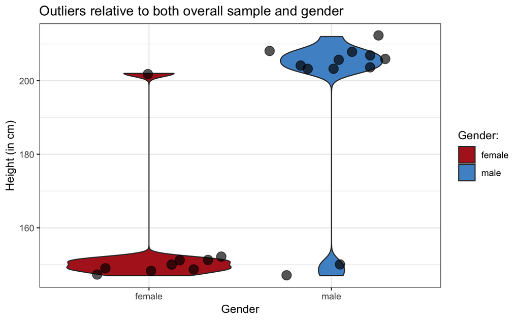

```r
# Visualization and interpretation of both types of outliers:

# 1. Showing out_1:
ggplot(out_1, aes(x = sex, y = height)) +
  geom_violin(aes(fill = sex)) +
  geom_jitter(size = 4, alpha = 2/3) +
  scale_fill_manual(values = c("firebrick", "steelblue3")) +
  labs(title = "Outliers relative to both overall sample and gender",
       x = "Gender", y = "Height (in cm)",
       fill = "Gender:") +
  theme_bw()
```

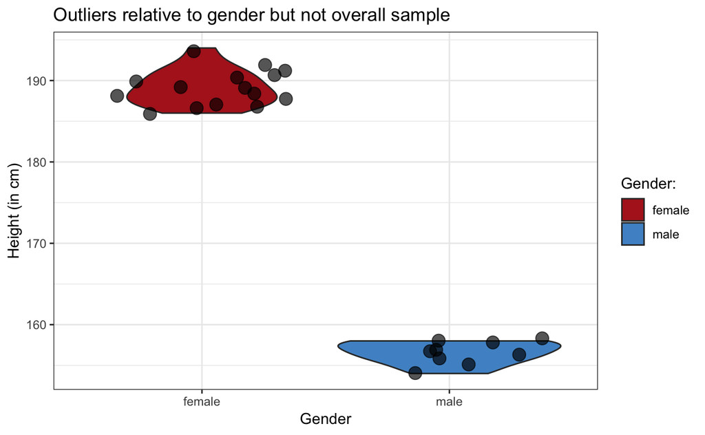

```r
# Interpretation:
# `out_1` contains mostly short women (except for 1 tall woman)
#  and mostly tall men (except for 2 short men).

# 2. Showing out_2:
ggplot(out_2, aes(x = sex, y = height)) +
  geom_violin(aes(fill = sex)) +
  geom_jitter(size = 4, alpha = 2/3) +
  scale_fill_manual(values = c("firebrick", "steelblue3")) +
  labs(title = "Outliers relative to gender but not overall sample",
       x = "Gender", y = "Height (in cm)",
       fill = "Gender:") +
  theme_bw()
```

```r
# Interpretation:
# `out_2` contains individuals which are either tall women or short men.
```

## Exercise 4

In [Exercise 6 of WPA01](http://rpository.com/ds4psy/essentials/basics.html#exercise-6) and [Exercise 5 of WPA02](http://rpository.com/ds4psy/essentials/visualize.html#exercise-5) you used the `p_info` data (available at http://rpository.com/ds4psy/data/posPsy_participants.csv) from

- Woodworth, R. J., O’Brien-Malone, A., Diamond, M. R. and Schüz, B. (2018). Data from, ‘Web-based positive psychology interventions: A reexamination of effectiveness’. *Journal of Open Psychology Data*, *6*: 1. DOI: https://doi.org/10.5334/jopd.35

to explore the participant information and create some corresponding plots.

```r
library(readr)

# Read data (from online source):
p_info <- read_csv(file = "http://rpository.com/ds4psy/data/posPsy_participants.csv")

# p_info
dim(p_info)      # 295 rows, 6 columns
```

```
#> [1] 295   6
```

Answer the same questions as in those exercises by transforming your earlier base R commands and graphs (created by using `ggplot2` commands) into pipes of `dplyr` commands that provide the same information.

#### From WPA01: Exercise 6

Questions from [Exercise 6 of WPA01](http://rpository.com/ds4psy/essentials/basics.html#exercise-6):

Examine the participant information in `p_info` by describing each of its variables:

1. How many individuals are contained in the dataset?
2. What percentage of them is female (i.e., has a `sex` value of 1)?
3. How many participants were in one of the 3 treatment groups (i.e., have an `intervention` value of 1, 2, or 3)?
4. What is the participants’ mean education level? What percentage has a university degree (i.e., an `educ` value of at least 4)?
5. What is the age range (`min` to `max`) of participants? What is the average (mean and median) age?
6. Describe the range of `income` levels present in this sample of participants. What percentage of participants self-identifies as a below-average income (i.e., an `income` value of 1)?

```r
# 1. How many individuals are contained in the dataset?
N <- nrow(p_info) # OR
N  # 295
```

```
#> [1] 295
```

```r
# Note:
p_info %>% count()
```

```
#> # A tibble: 1 x 1
#>       n
#>   <int>
#> 1   295
```

```r
# would yield a tibble (with only 1 element: 295).

# 2. What percentage of them is female (i.e., has a `sex` value of 1)?
p_info %>%
  group_by(sex) %>%
  summarise(n_sex = n(),            # number
            pc_sex = n_sex/N * 100  # percentage
            )
```

```
#> # A tibble: 2 x 3
#>     sex n_sex pc_sex
#>   <int> <int>  <dbl>
#> 1     1   251   85.1
#> 2     2    44   14.9
```

```r
# 3. How many participants were in one of the 3 treatment groups (i.e., have an `intervention` value of 1, 2, or 3)?
p_info %>%
  filter(intervention < 4) %>%
  count()
```

```
#> # A tibble: 1 x 1
#>       n
#>   <int>
#> 1   222
```

```r
# => 222 individuals

# OR:
t_iv <- p_info %>%
  group_by(intervention) %>%
  summarise(n_iv = n(),           # number
            pc_iv = n_iv/N * 100  # percentage
            )
t_iv
```

```
#> # A tibble: 4 x 3
#>   intervention  n_iv pc_iv
#>          <int> <int> <dbl>
#> 1            1    72  24.4
#> 2            2    76  25.8
#> 3            3    74  25.1
#> 4            4    73  24.7
```

```r
sum(t_iv$n_iv[1:3])
```

```
#> [1] 222
```

```r
# => 222 in elements 1:3 of vector n_iv


# 4. What is the participants' mean education level?
p_info %>%
  summarise(mn_edu = mean(educ))
```

```
#> # A tibble: 1 x 1
#>   mn_edu
#>    <dbl>
#> 1   3.98
```

```r
# What percentage has a university degree (i.e., an `educ` value of at least 4)?
p_info %>%
  group_by(educ) %>%
  summarise(n_edu = n(),            # number
            pc_edu = n_edu/N * 100  # percentage
            )
```

```
#> # A tibble: 5 x 3
#>    educ n_edu pc_edu
#>   <int> <int>  <dbl>
#> 1     1    14   4.75
#> 2     2    21   7.12
#> 3     3    39  13.2
#> 4     4   104  35.3
#> 5     5   117  39.7
```

```r
# 5. What is the age range (`min` to `max`) of participants?
#    What is the average (mean and median) age?
p_info %>%
  summarise(n = n(),
            min_age = min(age),
            mn_age = mean(age),
            max_age = max(age))
```

```
#> # A tibble: 1 x 4
#>       n min_age mn_age max_age
#>   <int>   <dbl>  <dbl>   <dbl>
#> 1   295      18   43.8      83
```

```r
# 6. Describe the range of `income` levels present in this sample of participants.
#    What percentage of participants self-identifies as a below-average income
#    (i.e., an `income` value of 1)?
p_info %>%
  group_by(income) %>%
  summarise(n_income = n(),
            pc_income = n_income/N * 100)
```

```
#> # A tibble: 3 x 3
#>   income n_income pc_income
#>    <int>    <int>     <dbl>
#> 1      1       73      24.7
#> 2      2      136      46.1
#> 3      3       86      29.2
```

#### From WPA02: Exercise 5

Questions from [Exercise 5 of WPA02](http://rpository.com/ds4psy/essentials/visualize.html#exercise-5)

Use the `p_info` data to create some plots that descripte the sample of participants:

- A *histogram* that shows the distribution of participant `age` in 3 ways:
  - overall,
  - separately for each `sex`, and
  - separately for each `intervention`.

When using `dplyr` instead of `ggplot2`, we can replace the information contained in the histogram by a table of descriptives:

```r
# Age distribution (as a table):
age_overall <- p_info %>%
  summarise(n = n(),              # number
            min_age = min(age),   # minimum
            mn_age = mean(age),   # mean
            md_age = median(age), # median
            sd_age = sd(age),     # standard deviation
            max_age = max(age)    # maximum
  )
age_overall
```

```
#> # A tibble: 1 x 6
#>       n min_age mn_age md_age sd_age max_age
#>   <int>   <dbl>  <dbl>  <int>  <dbl>   <dbl>
#> 1   295      18   43.8     44   12.4      83
```

```r
# Age distribution by sex (as a table):
age_by_sex <- p_info %>%
  group_by(sex) %>%
  summarise(n = n(),              # number
            min_age = min(age),   # minimum
            mn_age = mean(age),   # mean
            md_age = median(age), # median
            sd_age = sd(age),     # standard deviation
            max_age = max(age)    # maximum
  )
age_by_sex
```

```
#> # A tibble: 2 x 7
#>     sex     n min_age mn_age md_age sd_age max_age
#>   <int> <int>   <dbl>  <dbl>  <dbl>  <dbl>   <dbl>
#> 1     1   251      19   43.9     44   12.1      83
#> 2     2    44      18   43.0     44   14.1      71
```

```r
# Age distribution by intervention (as a table):
age_by_iv <- p_info %>%
  group_by(intervention) %>%
  summarise(n = n(),              # number
            min_age = min(age),   # minimum
            mn_age = mean(age),   # mean
            md_age = median(age), # median
            sd_age = sd(age),     # standard deviation
            max_age = max(age)    # maximum
  )
age_by_iv
```

```
#> # A tibble: 4 x 7
#>   intervention     n min_age mn_age md_age sd_age max_age
#>          <int> <int>   <dbl>  <dbl>  <dbl>  <dbl>   <dbl>
#> 1            1    72      22   44.6   45     12.1      71
#> 2            2    76      18   45.4   45.5   12.5      83
#> 3            3    74      19   43.3   44     12.2      71
#> 4            4    73      19   41.7   40     12.8      75
```

- A *bar plot* that
  - shows how many participants took part in each `intervention`; or
  - shows how many participants of each `sex` took part in each `intervention`.

Using `dplyr` instead of `ggplot2`:

```r
# Number of participants per intervention:
# (was contained in age_by_iv above):
age_by_iv %>%
  select(intervention, n)
```

```
#> # A tibble: 4 x 2
#>   intervention     n
#>          <int> <int>
#> 1            1    72
#> 2            2    76
#> 3            3    74
#> 4            4    73
```

```r
# N and percentage by intervention and sex:
p_info %>%
  group_by(intervention, sex) %>%
  summarise(n_iv_sex  = n(),              # number
            pc_iv_sex = n_iv_sex/N * 100  # percentage
            )
```

```
#> # A tibble: 8 x 4
#> # Groups:   intervention [?]
#>   intervention   sex n_iv_sex pc_iv_sex
#>          <int> <int>    <int>     <dbl>
#> 1            1     1       62     21.0
#> 2            1     2       10      3.39
#> 3            2     1       66     22.4
#> 4            2     2       10      3.39
#> 5            3     1       62     21.0
#> 6            3     2       12      4.07
#> 7            4     1       61     20.7
#> 8            4     2       12      4.07
```

# More on data transformation

For more details on `dplyr`,

- study `vignette("dplyr")` and the documentation for `?arrange`, `?filter`, `?select`, etc.
- study https://dplyr.tidyverse.org/ and its examples;
- see the [cheat sheet on data transformation](https://www.rstudio.com/resources/cheatsheets/);
- read [Chapter 5: Data transformation](http://r4ds.had.co.nz/transform.html) and complete its exercises.

# Conclusion

All [ds4psy](http://rpository.com/ds4psy/) essentials so far:

| Nr. | Topic |
| --- | --- |
| 0. | [Syllabus](http://rpository.com/ds4psy/) |
| 1. | [Basic R concepts and commands](http://rpository.com/ds4psy/essentials/basics.html) |
| 2. | [Visualizing data](http://rpository.com/ds4psy/essentials/visualize.html) |
| 3. | [Transforming data](http://rpository.com/ds4psy/essentials/transform.html) |
| 4. | [Exploring data (EDA)](http://rpository.com/ds4psy/essentials/explore.html) |
| 5. | [Tibbles](http://rpository.com/ds4psy/essentials/tibbles.html) |
| 6. | [Importing data](http://rpository.com/ds4psy/essentials/import.html) |
| 7. | [Tidying data](http://rpository.com/ds4psy/essentials/tidy.html) |
| 8. | [Joining data](http://rpository.com/ds4psy/essentials/join.html) |
| 9. | [Functions](http://rpository.com/ds4psy/essentials/function.html) |
| 10. | [Iteration](http://rpository.com/ds4psy/essentials/iteration.html) |
| +. | [Datasets](http://rpository.com/ds4psy/essentials/datasets.html) |

[Last update on 2019-05-04 13:06:04 by [hn](http://neth.de/).]